# Final Project

##### From the scatter plot, the positive linearity is significant.

#### 4.The fourth numerical variable I would like to include is percentage of English less than very well. This is an essential variable for socioeconomic quintile (the fifth) of my project. The range of this variable is from 0 to 1.

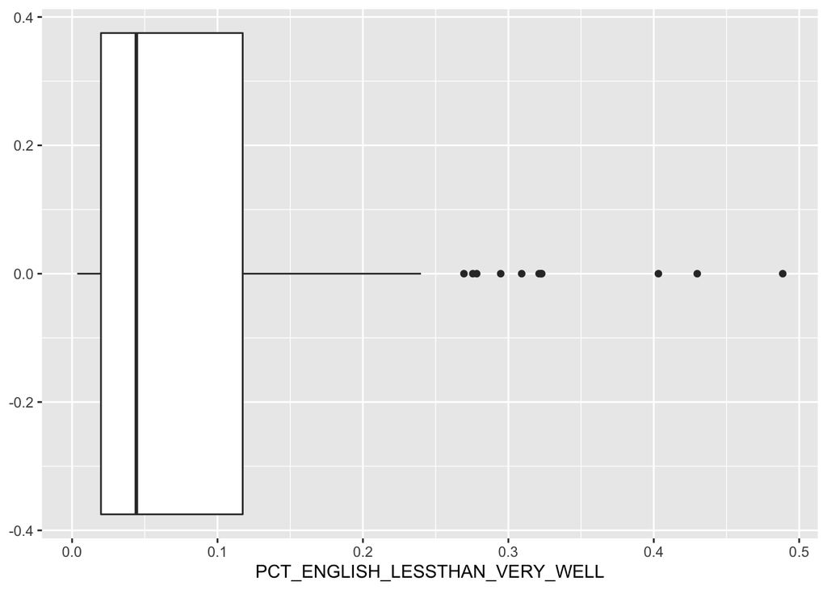

```r
ggplot()+
  geom_boxplot(data=rawdata,mapping=aes(x=PCT_ENGLISH_LESSTHAN_VERY_WELL))
```

##### From the plot, the median is around 4%, but the outliers can be up to 50%.

#### 5.The fifth variable I would like to include is a categorical variable, socioeconomic quintile. It is equally divided in five levels, lowest, second lowest, middle, second highest and most advantaged. This is the final result I would like to link it with every variable above.

```r
 rawdata%>%count(SOCIOECONOMIC_QUINTILE)
```

```
## # A tibble: 6 × 2
##   SOCIOECONOMIC_QUINTILE                  n
##   <chr>                               <int>
## 1 Highest priority/Most disadvantaged    28
## 2 Lowest                                 25
## 3 Middle                                 27
## 4 Second highest                         27
## 5 Second lowest                          27
## 6 <NA>                                    1
```

```r
#There is about 27 members in each of the five groups.
```

#### 6.The sixth variable is also a categorical variable, composite quintile. It is equally divided in five levels, lowest, second lowest, middle, second highest and most advantaged. The reason to include the composite quantile is to analyze the relationships between the variables above and the composite one include other variables (other than the above five).

```r
 rawdata%>%count(COMPOSITE_QUINTILE)
```

```
## # A tibble: 6 × 2
##   COMPOSITE_QUINTILE                      n
##   <chr>                               <int>
## 1 Highest priority/Most disadvantaged    28
## 2 Lowest                                 26
## 3 Middle                                 26
## 4 Second highest                         27
## 5 Second lowest                          27
## 6 <NA>                                    1
```

## Wrangle the data

```r
df<-as_tibble(rawdata)
glimpse(df)
```

```
## Rows: 135
## Columns: 39
## $ OBJECTID                       <dbl> 1, 2, 3, 4, 5, 6, 7, 8, 9, 10, 11, 12, …
## $ GEOID10                        <dbl> 53033005900, 53033004700, 53033001900, …
## $ NAME10                         <dbl> 59.00, 47.00, 19.00, 13.00, 41.00, 50.0…
## $ NAMELSAD10                     <chr> "Census Tract 59", "Census Tract 47", "…
## $ ACRES_TOTAL                    <dbl> 447.91951, 490.84574, 410.97098, 292.55…
## $ PCT_PEOPLE_OF_COLOR            <dbl> 0.1845367, 0.1812838, 0.3017331, 0.4054…
## $ PTL_PEOPLE_OF_COLOR            <dbl> 0.241, 0.211, 0.557, 0.692, 0.158, 0.25…
## $ PCT_ENGLISH_LESSTHAN_VERY_WELL <dbl> 0.01304059, 0.03845224, 0.07926566, 0.1…
## $ PTL_ENGLISH_LESSTHAN_VERY_WELL <dbl> 0.098, 0.444, 0.647, 0.767, 0.519, 0.36…
## $ PCT_FOREIGN_BORN               <dbl> 0.09533546, 0.10556644, 0.19189810, 0.2…
## $ PTL_FOREIGN_BORN               <dbl> 0.241, 0.294, 0.655, 0.730, 0.549, 0.34…
## $ PCT_POP_INC_UNDER_200_POVERTY  <dbl> 0.19525605, 0.17024221, 0.21161563, 0.2…
## $ PTL_POP_INC_UNDER_200_POVERTY  <dbl> 0.482, 0.384, 0.519, 0.549, 0.158, 0.51…
```

[output cut: 26 more lines]

```r
head(df)
```

```
## # A tibble: 6 × 39
##   OBJECTID     GEOID10 NAME10 NAMELSAD10      ACRES_TOTAL PCT_PEOPLE_OF_COLOR
##      <dbl>       <dbl>  <dbl> <chr>                 <dbl>               <dbl>
## 1        1 53033005900     59 Census Tract 59        448.               0.185
## 2        2 53033004700     47 Census Tract 47        491.               0.181
## 3        3 53033001900     19 Census Tract 19        411.               0.302
## 4        4 53033001300     13 Census Tract 13        293.               0.405
## 5        5 53033004100     41 Census Tract 41        788.               0.164
## 6        6 53033005000     50 Census Tract 50        187.               0.190
## # … with 33 more variables: PTL_PEOPLE_OF_COLOR <dbl>,
## #   PCT_ENGLISH_LESSTHAN_VERY_WELL <dbl>, PTL_ENGLISH_LESSTHAN_VERY_WELL <dbl>,
## #   PCT_FOREIGN_BORN <dbl>, PTL_FOREIGN_BORN <dbl>,
## #   PCT_POP_INC_UNDER_200_POVERTY <dbl>, PTL_POP_INC_UNDER_200_POVERTY <dbl>,
## #   PCT_LESS_BACHELOR_DEGREE <dbl>, PTL_LESS_BACHELOR_DEGREE <dbl>,
## #   PCT_ADULTNOLEISUREPHYSACTIVITY <dbl>, PCT_ADULT_WITH_DIABETES <dbl>,
## #   PCT_ADULT_OBESE <dbl>, PCT_ADULTMENTALHEALTHNOTGOOD <dbl>, …
```

```r
dim(df)
```

```
## [1] 135  39
```

```r
#there are 135 rows with 39 columns (39 variables of the raw data)
Colored_people_pct <- df[,6]
English_lessthanverywell_pct <- df[,8]
Diabetes_pct<-df[,17]
Asthma_pct<-df[,20]
Socialeconomic<-df[,35]
Composite_raw<-df[,31]
df1<-bind_cols(Colored_people_pct,English_lessthanverywell_pct,Diabetes_pct,Asthma_pct,Socialeconomic,Composite_raw)
dim(df1)
```

```
## [1] 135   6
```

##### 6 of the variables are chosen with 2 of them as categorical variables.

##### The categorical variables (socialeconimic quintile and the composite quintile) are the ones that I am trying to connect every these numerical variables with regression models.

##### The main propose of the project is to build a proper regression model, with different distribution.

##### My hypothesis here is that to predict a categorical variable, the simple liner regression would not be a perfect fit, and I will use anova test to verify it.

#### Remove the duplicated data (if any).

```r
df1_removed<-df1%>%distinct(.keep_all=TRUE)
df1[duplicated(df1),]
```

```
## # A tibble: 0 × 6
## # … with 6 variables: PCT_PEOPLE_OF_COLOR <dbl>,
## #   PCT_ENGLISH_LESSTHAN_VERY_WELL <dbl>, PCT_ADULT_WITH_DIABETES <dbl>,
## #   PCT_ADULT_WITH_ASTHMA <dbl>, SOCIOECONOMIC_QUINTILE <chr>,
## #   COMPOSITE_QUINTILE <chr>
```

```r
# no duplicated data
dim(df1_removed)
```

```
## [1] 135   6
```

##### we can tell that there is no duplicated data in the dataset with the exact same dimension after removing it.

#### Checking for the missing values.

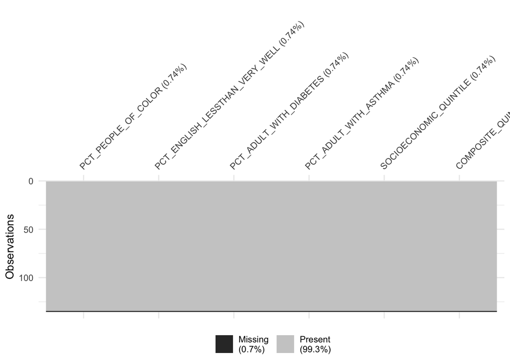

```r
library("visdat")
vis_miss(df1_removed)
```

```r
# There are minor missing values in the dataset (0.7%) at the very bottom (the last row)
df1_noms<-na.omit(df1_removed)
dim(df1_noms)
```

```
## [1] 134   6
```

```r
# one row of missing value is dropped.
```

#### Converting the categorical variable into numerical ones for regression

```r
df1_cate<-as.data.frame(df1_noms)
# Converting variables into categorical variables with R.
names(df1_cate)[1]<-paste("Colored_people_pct")
names(df1_cate)[2]<-paste("English_lessthanverywell_pct")
names(df1_cate)[3]<-paste("Diabetes_pct")
names(df1_cate)[4]<-paste("Asthma_pct")
names(df1_cate)[5]<-paste("Socialecon")
names(df1_cate)[6]<-paste("Composite")

summary(df1_cate)
```

```
##  Colored_people_pct English_lessthanverywell_pct  Diabetes_pct
##  Min.   :0.07861    Min.   :0.003543             Min.   :0.01200
##  1st Qu.:0.18822    1st Qu.:0.019861             1st Qu.:0.04925
##  Median :0.27328    Median :0.044194             Median :0.06350
##  Mean   :0.34449    Mean   :0.086765             Mean   :0.06849
##  3rd Qu.:0.44459    3rd Qu.:0.117335             3rd Qu.:0.07675
##  Max.   :0.91288    Max.   :0.488684             Max.   :0.17700
##    Asthma_pct       Socialecon         Composite
##  Min.   :0.08000   Length:134         Length:134
##  1st Qu.:0.08500   Class :character   Class :character
##  Median :0.08700   Mode  :character   Mode  :character
##  Mean   :0.08933
##  3rd Qu.:0.09275
##  Max.   :0.11400
```

```r
for (i in 5:6) df1_cate[,i] = factor(df1_cate[,i])

names(df1_cate)[5]<-paste("Socialecon")
df2<-df1_cate%>%
  mutate(Socialecon=if_else(Socialecon=="Highest priority/Most disadvantaged",5,
                   if_else(Socialecon=="Second highest",4,
                           if_else(Socialecon=="Middle",3,
                                   if_else(Socialecon=="Second lowest",2,1)))))
```

##### For building a linear relationship with numerical variables and cateorical ones, I firstly index the categorical variables. Giving the five ranks, I index each level with a number from 1 to 5.

```r
names(df2)[6]<-paste("Composite")
df3<-df2%>%
  mutate(Composite=if_else(Composite=="Highest priority/Most disadvantaged",5,
                   if_else(Composite=="Second highest",4,
                           if_else(Composite=="Middle",3,
                                   if_else(Composite=="Second lowest",2,1)))))
names(df3)[1]<-paste("Colored_people_pct")
names(df3)[2]<-paste("English_lessthanverywell_pct")
names(df3)[3]<-paste("Diabetes_pct")
names(df3)[4]<-paste("Asthma_pct")
names(df3)[5]<-paste("Socialecon_num")
names(df3)[6]<-paste("Composite_num")
head(df3)
```

```
##   Colored_people_pct English_lessthanverywell_pct Diabetes_pct Asthma_pct
## 1          0.1845367                   0.01304059        0.044      0.095
## 2          0.1812838                   0.03845224        0.044      0.086
## 3          0.3017331                   0.07926566        0.061      0.089
## 4          0.4054550                   0.12756705        0.058      0.089
## 5          0.1644422                   0.04552694        0.060      0.082
## 6          0.1900263                   0.03079858        0.038      0.084
##   Socialecon_num Composite_num
## 1              2             1
## 2              3             2
## 3              3             4
## 4              4             4
## 5              1             1
## 6              3             2
```

##### Same with the composite one.

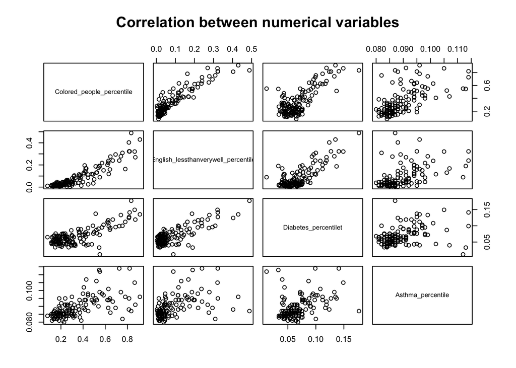

```r
pairs(df1_cate[,1:4],
      labels=c('Colored_people_percentile','English_lessthanverywell_percentile','Diabetes_percentilet','Asthma_percentile'),
               main='Correlation between numerical variables')
```

##### This is a big picture of how each of every numerical variables related to each other. The main purpose next step is to analyze the combined effect of them on socialsconomic level and composite status.

#### Categorical variables table

```r
ftable(xtabs(~ Socialecon + Composite, data = df1_cate))
```

```
##                                     Composite Highest priority/Most disadvantaged Lowest Middle Second highest Second lowest
## Socialecon
## Highest priority/Most disadvantaged                                            23      0      0              5             0
## Lowest                                                                          0     21      0              0             4
## Middle                                                                          0      0     18              3             6
## Second highest                                                                  5      0      3             19             0
## Second lowest                                                                   0      5      5              0            17
```

##### As one of my hypothesis, there is a strong positive correlation with socialeconomic and composite percentile.

## Regressions

#### Linear regression:

```r
lm1 = lm(Socialecon_num ~ Colored_people_pct+English_lessthanverywell_pct+Diabetes_pct+Asthma_pct,data=df3)
summary(lm1)
```

```
##
## Call:
## lm(formula = Socialecon_num ~ Colored_people_pct + English_lessthanverywell_pct +
##     Diabetes_pct + Asthma_pct, data = df3)
##
## Residuals:
##      Min       1Q   Median       3Q      Max
## -1.93192 -0.65987  0.01357  0.56062  1.80130
##
## Coefficients:
##                              Estimate Std. Error t value Pr(>|t|)
## (Intercept)                   -5.4704     1.0887  -5.025 1.65e-06 ***
## Colored_people_pct             3.2697     0.9278   3.524 0.000589 ***
## English_lessthanverywell_pct  -0.1494     1.8436  -0.081 0.935546
## Diabetes_pct                   6.0400     4.1649   1.450 0.149423
## Asthma_pct                    78.2285    12.7909   6.116 1.06e-08 ***
## ---
## Signif. codes:  0 '***' 0.001 '**' 0.01 '*' 0.05 '.' 0.1 ' ' 1
##
## Residual standard error: 0.7795 on 129 degrees of freedom
## Multiple R-squared:  0.7051, Adjusted R-squared:  0.6959
## F-statistic: 77.09 on 4 and 129 DF,  p-value: < 2.2e-16
```

```r
lm2 = lm(Composite_num ~ Colored_people_pct+English_lessthanverywell_pct+Diabetes_pct+Asthma_pct,data=df3)
summary(lm2)
```

```
##
## Call:
## lm(formula = Composite_num ~ Colored_people_pct + English_lessthanverywell_pct +
##     Diabetes_pct + Asthma_pct, data = df3)
##
## Residuals:
##      Min       1Q   Median       3Q      Max
## -1.84120 -0.60368 -0.00252  0.53191  1.54863
##
## Coefficients:
##                              Estimate Std. Error t value Pr(>|t|)
## (Intercept)                   -4.3257     0.9987  -4.331 2.95e-05 ***
## Colored_people_pct             4.7104     0.8511   5.534 1.67e-07 ***
## English_lessthanverywell_pct  -2.3154     1.6911  -1.369   0.1733
## Diabetes_pct                   8.9379     3.8205   2.339   0.0208 *
## Asthma_pct                    59.5731    11.7332   5.077 1.31e-06 ***
## ---
## Signif. codes:  0 '***' 0.001 '**' 0.01 '*' 0.05 '.' 0.1 ' ' 1
##
## Residual standard error: 0.715 on 129 degrees of freedom
## Multiple R-squared:  0.7556, Adjusted R-squared:  0.7481
## F-statistic: 99.72 on 4 and 129 DF,  p-value: < 2.2e-16
```

#### Non-linear Regression - Poisson

```r
ps1=glm(Socialecon_num ~ Colored_people_pct+English_lessthanverywell_pct+Diabetes_pct+Asthma_pct,family = "poisson", data = df3)
summary(ps1)
```

```
##
## Call:
## glm(formula = Socialecon_num ~ Colored_people_pct + English_lessthanverywell_pct +
##     Diabetes_pct + Asthma_pct, family = "poisson", data = df3)
##
## Deviance Residuals:
##      Min        1Q    Median        3Q       Max
## -1.19557  -0.37518   0.00675   0.36103   1.09221
##
## Coefficients:
##                              Estimate Std. Error z value Pr(>|z|)
## (Intercept)                   -1.1677     0.6877  -1.698   0.0895 .
## Colored_people_pct             1.1605     0.6312   1.839   0.0660 .
## English_lessthanverywell_pct  -0.3112     1.1905  -0.261   0.7938
## Diabetes_pct                   1.1200     2.7824   0.403   0.6873
## Asthma_pct                    19.8163     7.9601   2.489   0.0128 *
## ---
## Signif. codes:  0 '***' 0.001 '**' 0.01 '*' 0.05 '.' 0.1 ' ' 1
##
## (Dispersion parameter for poisson family taken to be 1)
##
##     Null deviance: 94.361  on 133  degrees of freedom
## Residual deviance: 39.307  on 129  degrees of freedom
## AIC: 436.29
##
## Number of Fisher Scoring iterations: 4
```

```r
ps2=glm(Composite_num ~ Colored_people_pct+English_lessthanverywell_pct+Diabetes_pct+Asthma_pct,family = "poisson", data = df3)
summary(ps2)
```

```
##
## Call:
## glm(formula = Composite_num ~ Colored_people_pct + English_lessthanverywell_pct +
##     Diabetes_pct + Asthma_pct, family = "poisson", data = df3)
##
## Deviance Residuals:
##      Min        1Q    Median        3Q       Max
## -1.13311  -0.43074   0.02738   0.36581   0.97941
##
## Coefficients:
##                              Estimate Std. Error z value Pr(>|z|)
## (Intercept)                   -0.9134     0.6884  -1.327   0.1845
## Colored_people_pct             1.5617     0.6212   2.514   0.0119 *
## English_lessthanverywell_pct  -0.8941     1.1751  -0.761   0.4467
## Diabetes_pct                   1.7151     2.8101   0.610   0.5417
## Asthma_pct                    15.4062     7.9866   1.929   0.0537 .
## ---
## Signif. codes:  0 '***' 0.001 '**' 0.01 '*' 0.05 '.' 0.1 ' ' 1
##
## (Dispersion parameter for poisson family taken to be 1)
##
##     Null deviance: 96.213  on 133  degrees of freedom
## Residual deviance: 35.910  on 129  degrees of freedom
## AIC: 431.9
##
## Number of Fisher Scoring iterations: 4
```

```r
anova(lm1,ps1)
```

```
## Analysis of Variance Table
##
## Model 1: Socialecon_num ~ Colored_people_pct + English_lessthanverywell_pct +
##     Diabetes_pct + Asthma_pct
## Model 2: Socialecon_num ~ Colored_people_pct + English_lessthanverywell_pct +
##     Diabetes_pct + Asthma_pct
##   Res.Df    RSS Df Sum of Sq F Pr(>F)
## 1    129 78.375
## 2    129 39.307  0    39.068
```

```r
anova(lm2,ps2)
```

```
## Analysis of Variance Table
##
## Model 1: Composite_num ~ Colored_people_pct + English_lessthanverywell_pct +
##     Diabetes_pct + Asthma_pct
## Model 2: Composite_num ~ Colored_people_pct + English_lessthanverywell_pct +
##     Diabetes_pct + Asthma_pct
##   Res.Df    RSS Df Sum of Sq F Pr(>F)
## 1    129 65.949
## 2    129 35.910  0    30.039
```

##### Based on ANOVA test of linear regression and poisson non-linear regression. We shall acknowledge that the residual sum of squares decreased from 78.375 to 39.307 from the linear regression model to the poisson regression model in the case of the relationship modeling of Socialeconomic quantile and other variables, and from 65.949 to 35.910 in the case of the relationship modeling of Composite quantile and other variables.

##### It is enough to prove that linear regression would not be as good as non-linear regression in these cases. The next step is to compare the poisson distribution with the logistic distribution.

#### Non-linear Regression - Logistic

```r
library(MASS)
log1 <- polr(Socialecon ~ Colored_people_pct+English_lessthanverywell_pct+Diabetes_pct+Asthma_pct, data = df1_cate, Hess=TRUE,method = c("logistic"))
summary(log1)
```

```
## Call:
## polr(formula = Socialecon ~ Colored_people_pct + English_lessthanverywell_pct +
##     Diabetes_pct + Asthma_pct, data = df1_cate, Hess = TRUE,
##     method = c("logistic"))
##
## Coefficients:
##                               Value Std. Error t value
## Colored_people_pct             3.10      2.321   1.336
## English_lessthanverywell_pct -14.04      5.141  -2.731
## Diabetes_pct                 -15.60     10.871  -1.435
## Asthma_pct                   -59.06     35.960  -1.642
##
## Intercepts:
##                                            Value    Std. Error t value
## Highest priority/Most disadvantaged|Lowest  -7.9854   3.0957    -2.5795
## Lowest|Middle                               -6.6806   3.0641    -2.1803
## Middle|Second highest                       -5.8209   3.0659    -1.8986
## Second highest|Second lowest                -4.7787   3.0626    -1.5603
##
## Residual Deviance: 382.6937
## AIC: 398.6937
```

```r
log2 <- polr(Composite ~ Colored_people_pct+English_lessthanverywell_pct+Diabetes_pct+Asthma_pct, data = df1_cate, Hess=TRUE,method = c("logistic"))
summary(log2)
```

```
## Call:
## polr(formula = Composite ~ Colored_people_pct + English_lessthanverywell_pct +
##     Diabetes_pct + Asthma_pct, data = df1_cate, Hess = TRUE,
##     method = c("logistic"))
##
## Coefficients:
##                                 Value Std. Error  t value
## Colored_people_pct            -0.2193      2.273 -0.09647
## English_lessthanverywell_pct -10.2285      5.308 -1.92704
## Diabetes_pct                 -25.9615     10.321 -2.51530
## Asthma_pct                     5.4785     34.292  0.15976
##
## Intercepts:
##                                            Value    Std. Error t value
## Highest priority/Most disadvantaged|Lowest  -3.7989   2.9841    -1.2731
## Lowest|Middle                               -2.3380   2.9646    -0.7886
## Middle|Second highest                       -1.4939   2.9742    -0.5023
## Second highest|Second lowest                -0.4416   2.9811    -0.1481
##
## Residual Deviance: 374.5893
## AIC: 390.5893
```

##### The rule of thumb in non-linear regression model is to choose the one with the least AIC. Comparing the Poisson distribution regression model and the logistic regression model we can tell both log1(the logistic regression model of between Socialeconomic quantile and other variables) and log2 (the logistic regression model of between Composite quantile and other variables)’s AIC is less than the poisson regression model (ps1 and ps2).

##### The specific number of AIC in socialeconomic quantile with other variables:

##### Poisson distribution (ps1) :436.29

##### Logistic distribution(log1): 398.6937

##### The specific number of AIC in Composite quantile with other variables:

##### Poisson distribution (ps2) :431.9

##### Logistic distribution (log2): 390.5893

## Conclusion: From the regression models and the tests above, the logistic model is the best fit overall for the regressions of the dataset.

#### Composite percentile = exp^(-0.2193 * colored people percentage-10.2285 * English less than well percentage-25.96* Diabete percentage+5.4785*asthma percentage)

#### Therefore, the variables above have mostly the negative correlation with socialeconomic status and composite status, which verifies my hypothesis. However, in the regression model of socialeconomic status and other variables, colored people percentage has a positive correlation with the socialeconomic quantile. In the regression model of Composite quantile and other variables, asthma percentage has a positive correlation with the socialeconomic percentile, which contradicts to my hypothesis.